# ga_kaggle

## Summary: Predicting customer revenue with Google Analytics data

The data come from [a Kaggle competition](https://www.kaggle.com/c/ga-customer-revenue-prediction). The objective is to predict the transaction revenue per customer, given a set of indicators from the GStore. In this notebook,

1. I first check and transform the data to gather all the necessary predictors.
2. Then, I do extensive exploratory data analyses that involves data visualization with matplotlib, seaborn and plotly.
3. Since less than 2% of all visitors decided to purchase, the sample is highly imbalanced. Thus, in order to predict the revenue per customer, I carry out a 2-step procedure:
   - First, try to classify buyers vs. non-buyers. Non-buyers obviously will give 0 revenue. Here, I compare the classifying accuracy scores with and without randomly under-sampling to balance out the training sample.
   - Second, given the sample of only the actual buyers, using regression models to predict the revenues.

     For both classification and regression, I will compare the performances of the models: Support Vector Machine, Logistic/Linear Regression, Decision Tree, Random Forest, AdaBoost with Decision Tree, Adaboost with Random Forest, Extreme Gradient Boosting library XGBoost, and Neural Networks.

In the end, XGBoost gives the best performances both in classification and in regression.

1. Data preparation
2. Exploratory data analysis
3. Classification and regression models
   - Classification models, including Classification with under-sampling
   - Regression models, including Hyperparameter tuning for the Neural Network model

## 1. Data wrangling

```python
import numpy as np
import pandas as pd
import matplotlib.pyplot as plt
import seaborn as sns
import plotly.graph_objects as go
import plotly.express as px
from plotly.subplots import make_subplots
import os
import json
from pandas.io.json import json_normalize
from datetime import datetime
import warnings
warnings.filterwarnings('ignore')

from sklearn import preprocessing
from sklearn.model_selection import train_test_split, KFold, cross_val_score, StratifiedKFold
from sklearn.linear_model import SGDClassifier, SGDRegressor
from sklearn.metrics import plot_roc_curve, mean_squared_error, accuracy_score, make_scorer
from sklearn.ensemble import RandomForestClassifier, RandomForestRegressor, AdaBoostRegressor, AdaBoostClassifier
from sklearn.tree import DecisionTreeClassifier, DecisionTreeRegressor
from sklearn.neural_network import MLPClassifier, MLPRegressor

import xgboost as xgb
from imblearn.under_sampling import RandomUnderSampler

pd.set_option('display.max_columns', None)
sns.set()

os.chdir("C:/Users/Nam/Desktop/Kaggle/ga-customer-revenue-prediction")

# %%
l_json=['device','geoNetwork','totals','trafficSource']

train=pd.read_csv("train.csv", low_memory=False, nrows=500000,
                  dtype={'fullVisitorId':'str'},
                  converters={col: json.loads for col in l_json})
```

```python
train['date']=pd.to_datetime(train.date, format='%Y%m%d')
train['visittime']=train.visitStartTime.apply(datetime.fromtimestamp)
train['weekday']=train.visittime.apply(lambda x: x.weekday())
train['day']=train.visittime.apply(lambda x: x.day)
train['month']=train.visittime.apply(lambda x: x.month)
train['year']=train.visittime.apply(lambda x: x.year)
train['hour']=train.visittime.apply(lambda x: x.hour)
```

```python
keys=['country','subContinent','browser','deviceCategory','pageviews','visits','transactionRevenue','source','medium','keyword']
indicators=['geoNetwork','geoNetwork','device','device','totals','totals','totals','trafficSource','trafficSource','trafficSource']

for k,ind in zip(keys, indicators):
    train[k]=[d[k] if k in d.keys() else np.nan for i,d in train[ind].iteritems()]

l_convert=['transactionRevenue','pageviews']
train[l_convert]=train[l_convert].astype('float')
```

```python
display('Columns: {}'.format(train.columns))
display(train.info())
display(train.head())
```

```
"Columns: Index(['channelGrouping', 'date', 'device', 'fullVisitorId', 'geoNetwork',\n       'sessionId', 'socialEngagementType', 'totals', 'trafficSource',\n       'visitId', 'visitNumber', 'visitStartTime', 'visittime', 'weekday',\n       'day', 'month', 'year', 'hour', 'country', 'subContinent', …
```

```
<class 'pandas.core.frame.DataFrame'>
RangeIndex: 500000 entries, 0 to 499999
Data columns (total 28 columns):
channelGrouping         500000 non-null object
date                    500000 non-null datetime64[ns]
device                  500000 non-null object
fullVisitorId           500000 non-null object
geoNetwork              500000 non-null object
sessionId               500000 non-null object
socialEngagementType    500000 non-null object
totals                  500000 non-null object
trafficSource           500000 non-null object
visitId                 500000 non-null int64
visitNumber             500000 non-null int64
visitStartTime          500000 non-null int64
visittime               500000 non-null datetime64[ns]
weekday                 500000 non-null int64
day                     500000 non-null int64
month                   500000 non-null int64
year                    500000 non-null int64
hour                    500000 non-null int64
country                 500000 non-null object
subContinent            500000 non-null object
browser                 500000 non-null object
deviceCategory          500000 non-null object
pageviews               499949 non-null float64
visits                  500000 non-null object
transactionRevenue      6425 non-null float64
source                  500000 non-null object
medium                  500000 non-null object
keyword                 214577 non-null object
dtypes: datetime64[ns](2), float64(2), int64(8), object(16)
memory usage: 106.8+ MB
```

```
None
```

|  | channelGrouping | date | device | fullVisitorId | geoNetwork | sessionId | socialEngagementType | totals | trafficSource | visitId | visitNumber | visitStartTime | visittime | weekday | day | month | year | hour | country | subContinent | browser | deviceCategory | pageviews | visits | transactionRevenue | source | medium | keyword |
| --- | --- | --- | --- | --- | --- | --- | --- | --- | --- | --- | --- | --- | --- | --- | --- | --- | --- | --- | --- | --- | --- | --- | --- | --- | --- | --- | --- | --- |
| 0 | Organic Search | 2016-09-02 | {'browser': 'Chrome', 'browserVersion': 'not a... | 1131660440785968503 | {'continent': 'Asia', 'subContinent': 'Western... | 1131660440785968503_1472830385 | Not Socially Engaged | {'visits': '1', 'hits': '1', 'pageviews': '1',... | {'campaign': '(not set)', 'source': 'google', ... | 1472830385 | 1 | 1472830385 | 2016-09-02 17:33:05 | 4 | 2 | 9 | 2016 | 17 | Turkey | Western Asia | Chrome | desktop | 1.0 | 1 | NaN | google | organic | (not provided) |
| 1 | Organic Search | 2016-09-02 | {'browser': 'Firefox', 'browserVersion': 'not ... | 377306020877927890 | {'continent': 'Oceania', 'subContinent': 'Aust... | 377306020877927890_1472880147 | Not Socially Engaged | {'visits': '1', 'hits': '1', 'pageviews': '1',... | {'campaign': '(not set)', 'source': 'google', ... | 1472880147 | 1 | 1472880147 | 2016-09-03 07:22:27 | 5 | 3 | 9 | 2016 | 7 | Australia | Australasia | Firefox | desktop | 1.0 | 1 | NaN | google | organic | (not provided) |
| 2 | Organic Search | 2016-09-02 | {'browser': 'Chrome', 'browserVersion': 'not a... | 3895546263509774583 | {'continent': 'Europe', 'subContinent': 'South... | 3895546263509774583_1472865386 | Not Socially Engaged | {'visits': '1', 'hits': '1', 'pageviews': '1',... | {'campaign': '(not set)', 'source': 'google', ... | 1472865386 | 1 | 1472865386 | 2016-09-03 03:16:26 | 5 | 3 | 9 | 2016 | 3 | Spain | Southern Europe | Chrome | desktop | 1.0 | 1 | NaN | google | organic | (not provided) |
| 3 | Organic Search | 2016-09-02 | {'browser': 'UC Browser', 'browserVersion': 'n... | 4763447161404445595 | {'continent': 'Asia', 'subContinent': 'Southea... | 4763447161404445595_1472881213 | Not Socially Engaged | {'visits': '1', 'hits': '1', 'pageviews': '1',... | {'campaign': '(not set)', 'source': 'google', ... | 1472881213 | 1 | 1472881213 | 2016-09-03 07:40:13 | 5 | 3 | 9 | 2016 | 7 | Indonesia | Southeast Asia | UC Browser | desktop | 1.0 | 1 | NaN | google | organic | google + online |
| 4 | Organic Search | 2016-09-02 | {'browser': 'Chrome', 'browserVersion': 'not a... | 27294437909732085 | {'continent': 'Europe', 'subContinent': 'North... | 27294437909732085_1472822600 | Not Socially Engaged | {'visits': '1', 'hits': '1', 'pageviews': '1',... | {'campaign': '(not set)', 'source': 'google', ... | 1472822600 | 2 | 1472822600 | 2016-09-02 15:23:20 | 4 | 2 | 9 | 2016 | 15 | United Kingdom | Northern Europe | Chrome | mobile | 1.0 | 1 | NaN | google | organic | (not provided) |

```python
display((train.isna().sum()/len(train)*100).sort_values(ascending=False).to_frame(name='%Null').head(10))
```

|  | %Null |
| --- | --- |
| transactionRevenue | 98.7150 |
| keyword | 57.0846 |
| pageviews | 0.0102 |
| visittime | 0.0000 |
| date | 0.0000 |
| device | 0.0000 |
| fullVisitorId | 0.0000 |
| geoNetwork | 0.0000 |
| sessionId | 0.0000 |
| socialEngagementType | 0.0000 |

## 2. Exploratory data analysis

#### Preparing functions to plot graphs:

```python
def PiePlot_Cat(df, var, target, top):
    fig=make_subplots(rows=1, cols=3, specs=[[{'type':'pie'},{'type':'pie'},{'type':'pie'}]],\
                     subplot_titles=['Visitors with zero '+target,'Visitors with positive '+target,'All visitors'])

    count=df[df[target].isna()][var].value_counts().sort_values(ascending=False).reset_index()
    count['index'][top:]='Others'
    fig.add_trace(go.Pie(labels=count['index'], values=count[var],\
                           textposition='inside'), row=1, col=1)

    count=df[~df[target].isna()][var].value_counts().sort_values(ascending=False).reset_index()
    count['index'][top:]='Others'
    fig.add_trace(go.Pie(labels=count['index'], values=count[var], \
                           textposition='inside'), row=1, col=2)

    count=df[var].value_counts().sort_values(ascending=False).reset_index()
    count['index'][top:]='Others'
    fig.add_trace(go.Pie(labels=count['index'], values=count[var], \
                           textposition='inside'), row=1, col=3)
    for i in fig['layout']['annotations']:
        i['font']['size']=12
        i['y']=0.85
    fig.update_layout(font=dict(size=12), legend_orientation='h', legend=dict(y=0.1), margin=dict(l=0, r=0, t=0, b=20)).show(renderer='png')

def BarPlot_Cat(df, var, target, top):
    fig=make_subplots(rows=1, cols=2, specs=[[{'type':'bar'},{'type':'bar'}]],\
                     subplot_titles=['Total '+target+' by top '+var,\
                                     'Conversion rate (positive '+target+')'+'<br>by '+var+' with most visitors'])
    total=df[target].groupby(df[var]).sum(skipna=True).sort_values(ascending=False).to_frame().reset_index()
    fig.append_trace({'x':total[:top][var], 'y':total[:top][target], 'type':'bar'}, 1,1)
    count=df[df[target].notna()][var].value_counts()
    purchased=(count/df[var].value_counts()).sort_values(ascending=False)
    fig.append_trace({'x':count.index[:top], 'y':purchased.loc[count.index[:top]].values, 'type':'bar'}, 1,2)
    fig.update_layout(height=350, showlegend=False, margin=dict(l=20, r=20, t=50, b=50)).show(renderer='png')

    subfig=make_subplots(specs=[[{"secondary_y":True}]])
    average=df[target].groupby(df[var]).mean().sort_values(ascending=False)
    subfig.add_trace(go.Bar(x=count.index[:top], y=average.loc[count.index[:top]].values,\
                         name='Average '+target+' per visitor'), secondary_y=False)
    subfig.add_trace(go.Scatter(x=count.index[:top], y=count.values[:top],\
                             name='Number of visitors with positive '+target), secondary_y=True)
    subfig.update_layout(title_text='Average '+target+' per visitor <br> by '+var+' with most visitors', legend=dict(x=1))
    subfig.update_layout(font=dict(size=12), height=300, margin=dict(l=20, r=20, t=50, b=20)).show(renderer='png')

def KDE_Plot(df, var, target, top):
    topvar=df.groupby(var)[target].sum().sort_values(ascending=False).index[:top]
    df=df[(df[target].notna()) & (df[var].isin(topvar.values))]
    plt.figure(figsize=(10,5))
    for i in df[var].unique():
        sns.kdeplot(df[df[var]==i][target].apply(np.log), label=str(i), shade=True)
    plt.title('Density of {} by {} with most visitors'.format(target, var))
    plt.legend()
    plt.show()
```

### Customer revenue per country

|  | Count All | Count non-NaN |
| --- | --- | --- |
| United States | 199337 | 6125.0 |
| India | 27531 | 6.0 |
| United Kingdom | 20057 | 11.0 |
| Vietnam | 16255 | NaN |
| Canada | 14148 | 98.0 |

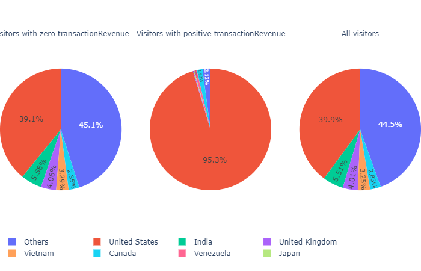

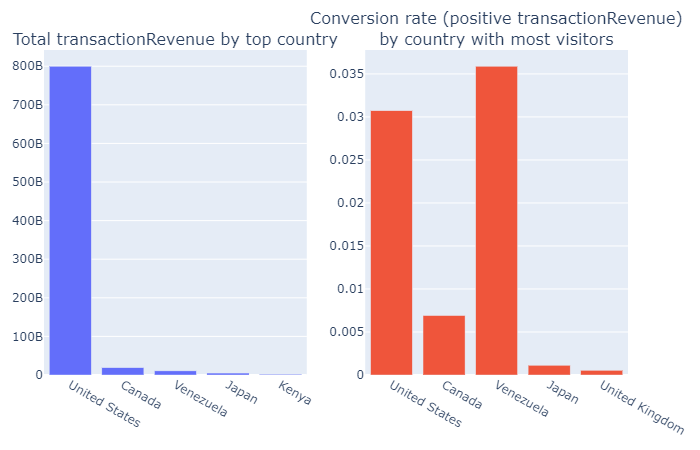

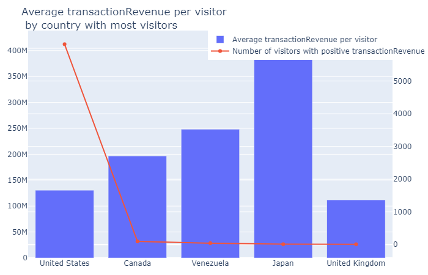

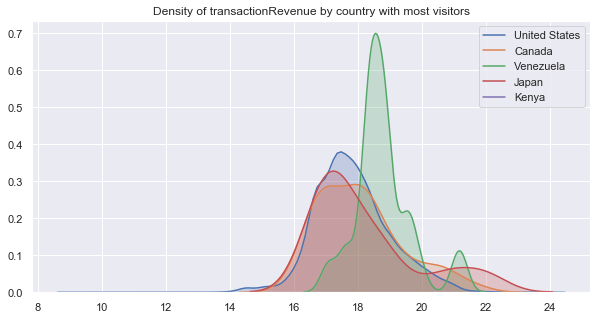

```python
target='transactionRevenue'
var='country'
top=5

display(train[var].value_counts().to_frame(name='Count All')
      .join(train[train[target].notna()][var].value_counts().to_frame(name='Count non-NaN')).head())

PiePlot_Cat(train, var, target, top)
BarPlot_Cat(train, var, target, top)
KDE_Plot(train, var, target, top)
```

### Customer revenue per web-browser type

|  | Count All | Count non-NaN |
| --- | --- | --- |
| Chrome | 342494 | 5791.0 |
| Safari | 103920 | 429.0 |
| Firefox | 20213 | 111.0 |
| Internet Explorer | 10704 | 57.0 |
| Edge | 5466 | 27.0 |

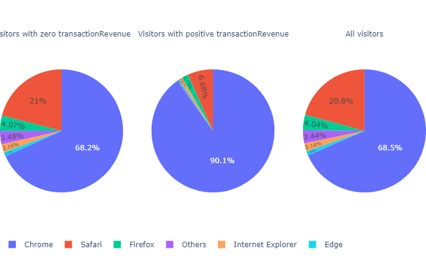

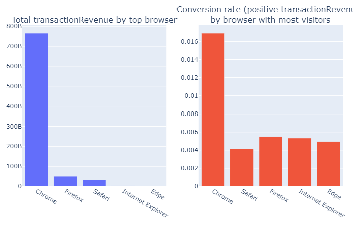

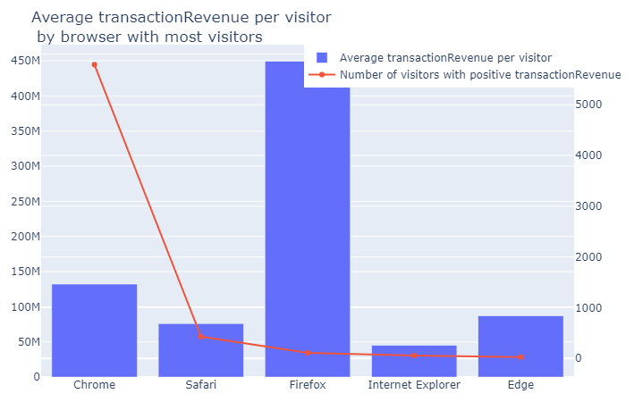

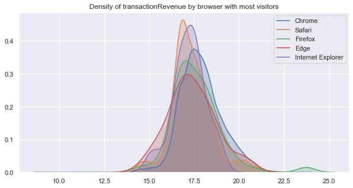

```python
target='transactionRevenue'
var='browser'
top=5

display(train[var].value_counts().to_frame(name='Count All')
      .join(train[train[target].notna()][var].value_counts().to_frame(name='Count non-NaN')).head())

PiePlot_Cat(train, var, target, top)
BarPlot_Cat(train, var, target, top)
KDE_Plot(train, var, target, top)
```

### Revenue by channel of reaching the webstore

|  | Count All | Count non-NaN |
| --- | --- | --- |
| organic | 203708 | 1873.0 |
| referral | 193117 | 3043.0 |
| (none) | 76924 | 1173.0 |
| cpc | 13800 | 258.0 |
| affiliate | 8898 | 2.0 |

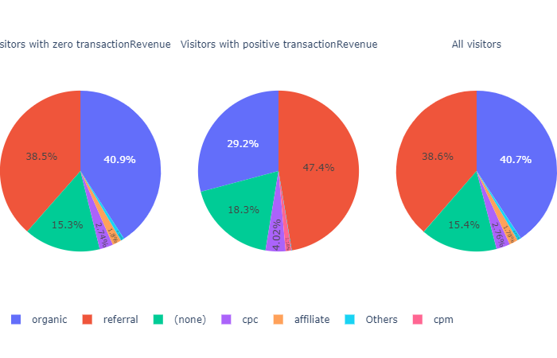

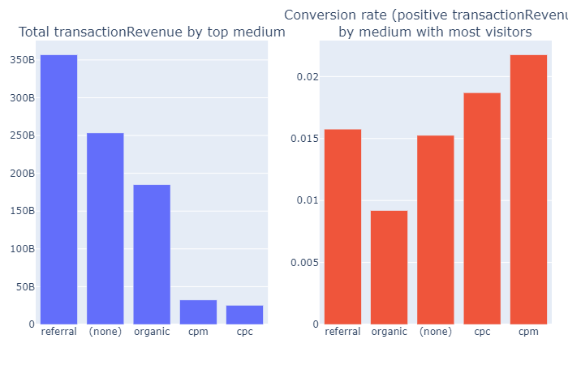

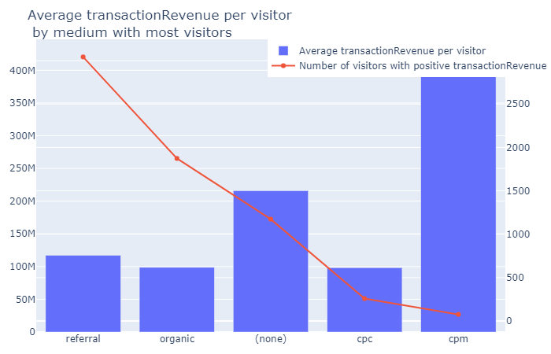

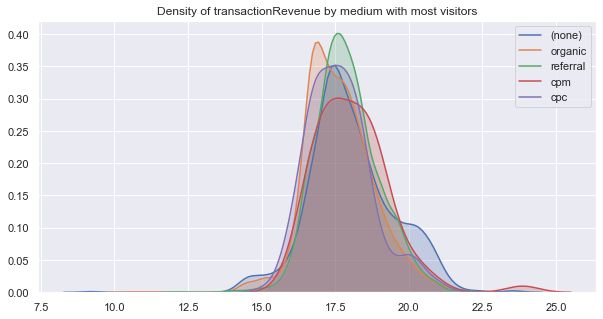

```python
target='transactionRevenue'
var='medium'
top=5

display(train[var].value_counts().to_frame(name='Count All')
      .join(train[train[target].notna()][var].value_counts().to_frame(name='Count non-NaN')).head())

PiePlot_Cat(train, var, target, top)
BarPlot_Cat(train, var, target, top)
KDE_Plot(train, var, target, top)
```

### Relationship with the numbers of pageviews

|  | pageviews |
| --- | --- |
| count | 499949.000000 |
| mean | 3.838011 |
| std | 7.051886 |
| min | 1.000000 |
| 25% | 1.000000 |
| 50% | 2.000000 |
| 75% | 4.000000 |
| max | 469.000000 |

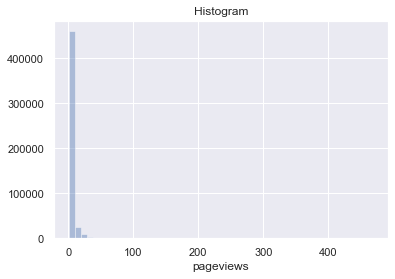

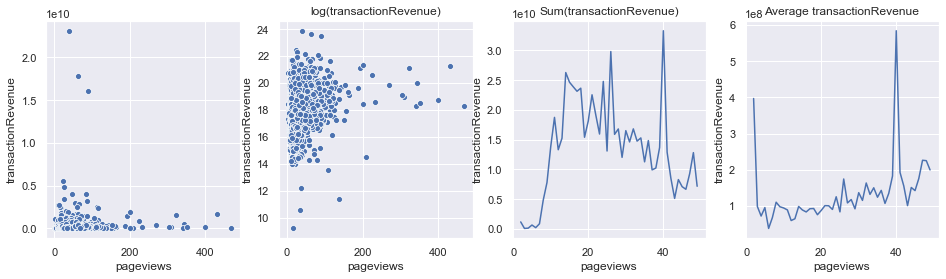

```python
df=train
indicator='pageviews'

display(df[indicator].describe().to_frame())
plt.figure()
sns.distplot(df[indicator].dropna(), kde=False)
plt.title('Histogram')
plt.show()

fig=plt.figure(figsize=(16,4))
fig.add_subplot(1,4,1)
sns.scatterplot(x=df[indicator], y=df[target])
fig.add_subplot(1,4,2)
sns.scatterplot(x=df[indicator], y=df[target].apply(np.log)).set_title('log({})'.format(target))
fig.add_subplot(1,4,3)
sns.lineplot(x=indicator, y=target, estimator=np.nansum, ci=None, \
             data=df[df[indicator].isin(range(50))]).set_title('Sum({})'.format(target))
fig.add_subplot(1,4,4)
sns.lineplot(x=indicator, y=target, estimator=np.nanmean, ci=None, \
             data=df[df[indicator].isin(range(50))]).set_title('Average {}'.format(target))
plt.show()
```

### Average revenues by year, month, date, weekday and hour in the day

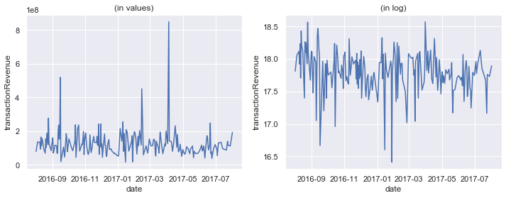

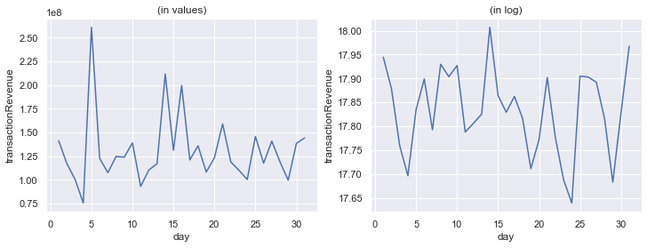

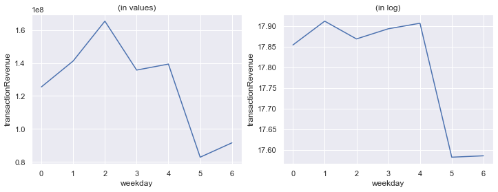

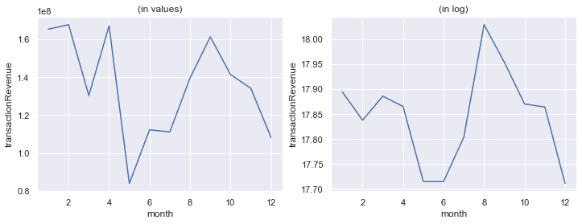

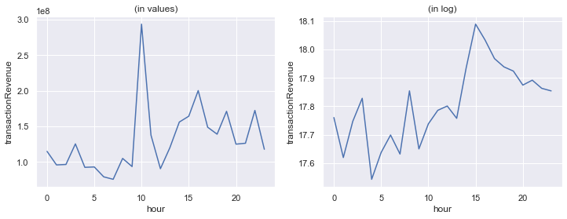

```python
df=train

def Date_Plot(df, indicator, target):
    fig=plt.figure(figsize=(12,4))
    fig.add_subplot(1,2,1)
    sns.lineplot(x=indicator, y=target, data=df, estimator=np.nanmean, ci=None).set_title('(in values)')
    fig.add_subplot(1,2,2)
    sns.lineplot(x=df[indicator], y=df[target].apply(np.log), estimator=np.nanmean, ci=None).set_title('(in log)')
    plt.show()

Date_Plot(df, 'date', 'transactionRevenue')
Date_Plot(df, 'day', 'transactionRevenue')
Date_Plot(df, 'weekday', 'transactionRevenue')
Date_Plot(df, 'month', 'transactionRevenue')
Date_Plot(df, 'hour', 'transactionRevenue')
```

## 3.Classification & Regression models

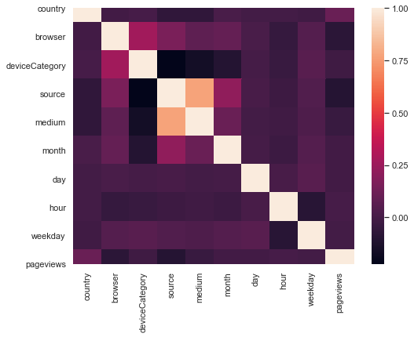

```python
df=train.copy()
l_cat=['country','browser','deviceCategory','source','medium']
for col in l_cat:
    df[col]=preprocessing.LabelEncoder().fit_transform(df[col])
l_cont=['month','day','hour','weekday','pageviews']
df[l_cat+l_cont]=df[l_cat+l_cont].fillna(0)

df_purchased=df[df.transactionRevenue.notna()]
df_nonpurchased=df[df.transactionRevenue.isna()]

X=(np.array(df[l_cat+l_cont]))
y=np.array(df['transactionRevenue'].notna())

plt.figure(figsize=(8,6))
sns.heatmap(df[l_cat+l_cont].corr())
plt.show()
```

```python
def features_plot(ax, mod, l_names, title):
    if 'feature_importances_' in mod.__dir__():
        feature_weights=pd.Series(mod.feature_importances_, index=l_names).sort_values(ascending=False)
    else:
        feature_weights=pd.Series(mod.coef_[0], index=l_names).sort_values(ascending=False)
    sns.barplot(ax=ax, x=feature_weights.values, y=feature_weights.index).set_title(title)
```

### 3.1 Classifcation: Buyers vs. Non-buyers

### Plotting feature importances per model

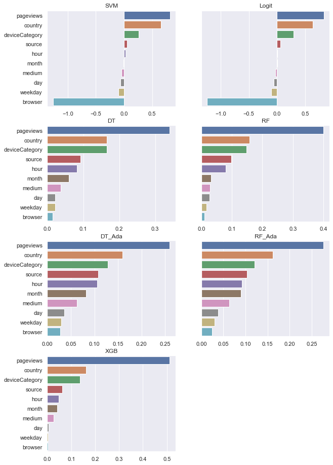

```python
X_train, X_test, y_train, y_test = train_test_split(X, y, test_size=0.2, random_state=0)

models=dict({'SVM':SGDClassifier(loss='hinge', max_iter=1000, tol=1e-3),\
            'Logit':SGDClassifier(loss='log', max_iter=1000, tol=1e-3),\
            'DT':DecisionTreeClassifier(),\
            'RF':RandomForestClassifier(n_estimators=3),\
            'DT_Ada':AdaBoostClassifier(DecisionTreeClassifier(max_depth=5)),\
            'RF_Ada':AdaBoostClassifier(RandomForestClassifier(max_depth=5,n_estimators=3)),\
            'XGB':xgb.XGBClassifier(n_estimators=100),\
            'NN':MLPClassifier()})

fig, ax=plt.subplots(4,2, sharey=True, figsize=(10,16))

for i, mod in enumerate(list(models.keys())[:-1]):
    models[mod].fit(X_train, y_train)
    features_plot(ax[i//2,i%2], models[mod], l_cat+l_cont, mod)

fig.delaxes(ax[3,1])
plt.show()
```

### Accuracy scores - Cross validation

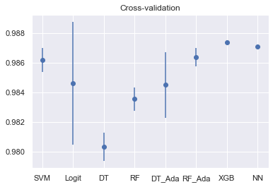

```python
NFold=5
scores=pd.DataFrame(index=range(NFold), columns=models.keys())

for mod in models.keys():
    scores[mod]=(cross_val_score(models[mod], X,y, cv=NFold))

plt.figure()
plt.errorbar(x=scores.columns.values, y=scores.mean(), yerr=scores.std(), fmt='o')
plt.title('Cross-validation')
plt.show()
```

### Plotting ROC curves

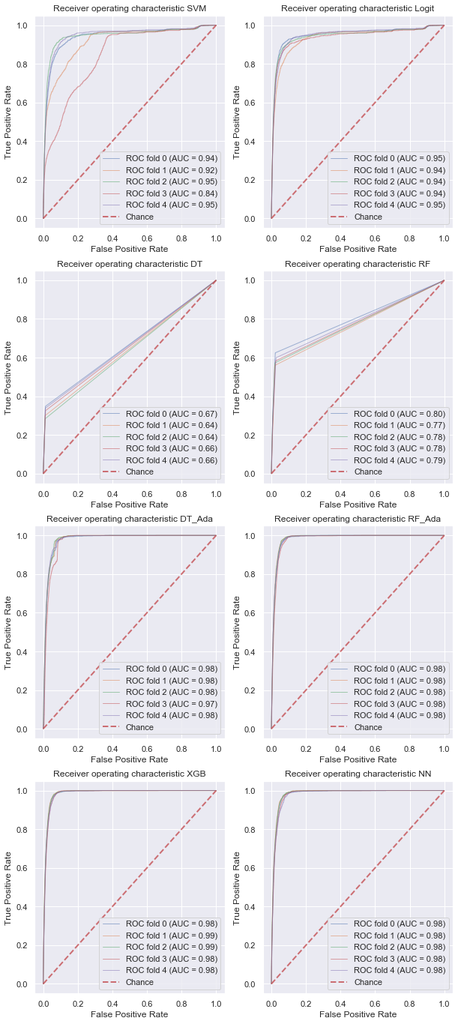

```python
def ROC_plot(classifier, cv, X, y, graph_title, ax):
    for i, (train, test) in enumerate(cv.split(X, y)):
        classifier.fit(X[train], y[train])
        plot_roc_curve(classifier, X[test], y[test],
                             name='ROC fold {}'.format(i),
                             alpha=0.5, lw=1, ax=ax)

    ax.plot([0, 1], [0, 1], linestyle='--', lw=2, color='r',
            label='Chance', alpha=.8)

    ax.set(xlim=[-0.05, 1.05], ylim=[-0.05, 1.05],
           title="Receiver operating characteristic {}".format(graph_title))
    ax.legend(loc="lower right")

cv = StratifiedKFold(n_splits=5)

fig, ax=plt.subplots(4,2,figsize=(10,24))
for i, mod in enumerate(models.keys()):
    ROC_plot(models[mod], cv, X, y, mod, ax[i//2,i%2])
fig.show()
```

### Recall scores: Buyers vs. Non-buyers

The sample is highly imbalanced: Most are non-buyers. The fitted models will be biased toward the non-buyer class, giving low recall scores in the case of buyers.

```
Recall scores: Buyers [0.0625, 0.2175632911392405, 0.8140822784810127, 0.7112341772151899, 0.3022151898734177, 0.28085443037974683, 0.12262658227848101, 0.06962025316455696]
Recall scores: Non-buyers [0.9990884783665532, 0.9966577540106952, 0.9976806838437855, 0.9976604278074866, 0.9974679954626479, 0.997670555825636, 0.9990479662939556, 0.9994024469291849]
```

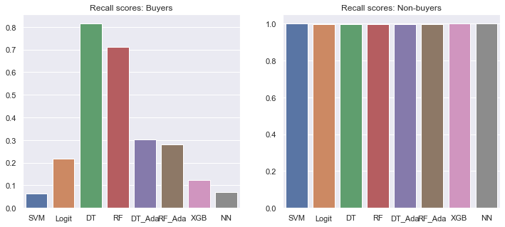

```python
def scores_plot(models, X, y, title, ax):
    scores=[accuracy_score(y, models[mod].predict(X)) for mod in models.keys()]
    sns.barplot(ax=ax, y=scores, x=list(models.keys())).set_title(title)
    print(title,scores)

X_pos=X_test[y_test>0,:]
y_pos=y_test[y_test>0]
X_neg=X_test[y_test==0,:]
y_neg=y_test[y_test==0]

fig, ax=plt.subplots(1,2,figsize=(12,5))
scores_plot(models, X_pos, y_pos, 'Recall scores: Buyers', ax[0])
scores_plot(models, X_neg, y_neg, 'Recall scores: Non-buyers', ax[1])
```

### Improve the classification performances by re-balancing the train sample with RandomUnderSampler

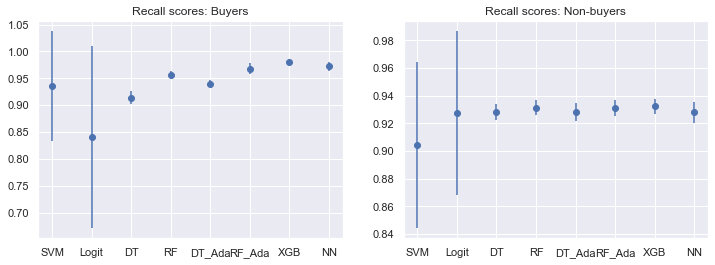

```python
models=dict({'SVM':SGDClassifier(loss='hinge', max_iter=1000, tol=1e-3),\
            'Logit':SGDClassifier(loss='log', max_iter=1000, tol=1e-3),\
            'DT':DecisionTreeClassifier(),\
            'RF':RandomForestClassifier(n_estimators=3),\
            'DT_Ada':AdaBoostClassifier(DecisionTreeClassifier(max_depth=5)),\
            'RF_Ada':AdaBoostClassifier(RandomForestClassifier(max_depth=5,n_estimators=3)),\
            'XGB':xgb.XGBClassifier(n_estimators=100),\
            'NN':MLPClassifier()})

scores_positive=pd.DataFrame(index=range(5), columns=models.keys())
scores_negative=pd.DataFrame(index=range(5), columns=models.keys())

kfold=StratifiedKFold(n_splits=5)
j=0
for i_train, i_test in kfold.split(X,y):
    X_train, y_train = RandomUnderSampler('majority').fit_resample(X[i_train,:], y[i_train])
    X_test, y_test = X[i_test,:], y[i_test]

    for mod in models.keys():
        models[mod].fit(X_train, y_train)

    X_pos=X_test[y_test>0,:]
    y_pos=y_test[y_test>0]
    X_neg=X_test[y_test==0,:]
    y_neg=y_test[y_test==0]

    scores_positive.loc[j]=[accuracy_score(y_pos, models[mod].predict(X_pos)) for mod in models.keys()]
    scores_negative.loc[j]=[accuracy_score(y_neg, models[mod].predict(X_neg)) for mod in models.keys()]
    j+=1

fig=plt.figure(figsize=(12,4))
fig.add_subplot(1,2,1)
plt.errorbar(x=scores_positive.columns.values, y=scores_positive.mean(), yerr=scores_positive.std(), fmt='o')
fig.add_subplot(1,2,2)
plt.errorbar(x=scores_negative.columns.values, y=scores_negative.mean(), yerr=scores_negative.std(), fmt='o')
fig.axes[0].set_title('Recall scores: Buyers')
fig.axes[1].set_title('Recall scores: Non-buyers')
fig.show()
```

### 3.2 Regression: Predicting the purchased values of the actual buyers

### Feature importances

```
[11:25:58] WARNING: src/objective/regression_obj.cu:152: reg:linear is now deprecated in favor of reg:squarederror.
```

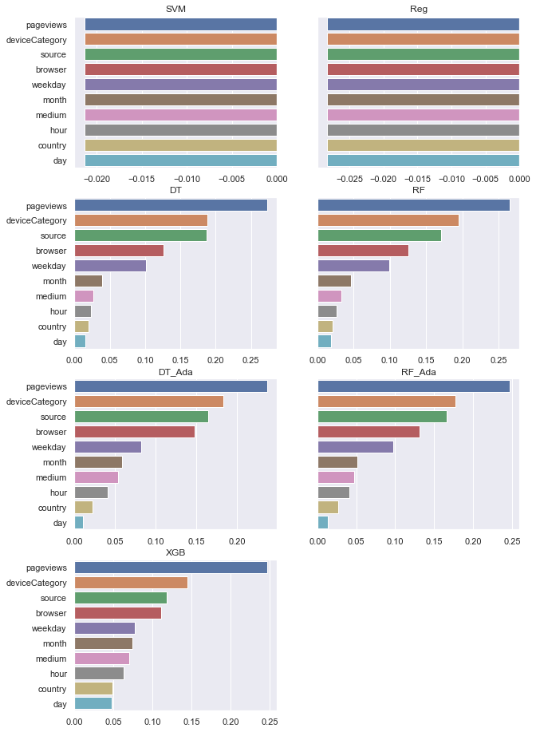

```python
X=preprocessing.scale(df_purchased[l_cat+l_cont])
y=np.array(df_purchased.transactionRevenue.apply(np.log))

models=dict({'SVM':SGDRegressor(loss='epsilon_insensitive'),\
            'Reg':SGDRegressor(loss='squared_loss'),\
            'DT':DecisionTreeRegressor(),\
            'RF':RandomForestRegressor(n_estimators=3),\
            'DT_Ada':AdaBoostRegressor(DecisionTreeRegressor(max_depth=5)),\
            'RF_Ada':AdaBoostRegressor(RandomForestRegressor(max_depth=5,n_estimators=3)),\
            'XGB':xgb.XGBRegressor(),\
            'NN':MLPRegressor()})

X_train, X_test, y_train, y_test = train_test_split(X, y, test_size=0.2, random_state=None)

fig, ax= plt.subplots(4,2, sharey=True, figsize=(10,16))

for i, mod in enumerate(list(models.keys())[:-1]):
    models[mod].fit(X_train, y_train)
    features_plot(ax[i//2,i%2], models[mod], l_cat+l_cont, mod)

fig.delaxes(ax[3,1])
fig.show()
```

### Regression: Cross-validation

[output not shown]

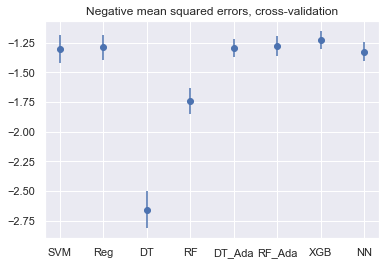

|  | Neg MSE |
| --- | --- |
| SVM | -1.303808 |
| Reg | -1.289180 |
| DT | -2.658723 |
| RF | -1.742098 |
| DT_Ada | -1.295095 |
| RF_Ada | -1.282844 |
| XGB | -1.226124 |
| NN | -1.326638 |

```python
NFold=5
scores=pd.DataFrame(index=range(NFold), columns=models.keys())

for mod in models.keys():
    scores[mod]=(cross_val_score(models[mod], X,y, cv=NFold, scoring='neg_mean_squared_error'))

plt.figure()
plt.errorbar(x=scores.columns.values, y=scores.mean(), yerr=scores.std(), fmt='o')
plt.title('Negative mean squared errors, cross-validation')
plt.show()
display(scores.mean().to_frame(name='Neg MSE'))
```

### Hyperparameter tuning for the neural-network model MLPRegressor

```python
from sklearn.model_selection import GridSearchCV

params={'activation':['relu','tanh'],\
       'solver':['lbfgs', 'sgd', 'adam'],\
        'learning_rate':['constant','adaptive'],\
       'alpha':[0.01,0.001,0.0001]}

clf=GridSearchCV(MLPRegressor(), params, cv=5, scoring='neg_mean_squared_error')
clf.fit(X, y)
```

```
GridSearchCV(cv=5, error_score=nan,
             estimator=MLPRegressor(activation='relu', alpha=0.0001,
                                    batch_size='auto', beta_1=0.9, beta_2=0.999,
                                    early_stopping=False, epsilon=1e-08,
                                    hidden_layer_sizes=(100,),
                                    learning_rate='constant',
                                    learning_rate_init=0.001, max_fun=15000,
                                    max_iter=200, momentum=0.9,
                                    n_iter_no_change=10,
                                    nesterovs_momentum=True, power_t=0.5,
                                    random_state=...
                                    solver='adam', tol=0.0001,
                                    validation_fraction=0.1, verbose=False,
                                    warm_start=False),
             iid='deprecated', n_jobs=None,
             param_grid={'activation': ['relu', 'tanh'],
                         'alpha': [0.01, 0.001, 0.0001],
                         'learning_rate': ['constant', 'adaptive'],
                         'solver': ['lbfgs', 'sgd', 'adam']},
             pre_dispatch='2*n_jobs', refit=True, return_train_score=False,
             scoring='neg_mean_squared_error', verbose=0)
```

|  | param_activation | param_alpha | param_solver | param_learning_rate | mean_test_score | std_test_score | rank_test_score |
| --- | --- | --- | --- | --- | --- | --- | --- |
| 22 | tanh | 0.01 | sgd | adaptive | -1.244137 | 0.080883 | 1 |
| 28 | tanh | 0.001 | sgd | adaptive | -1.244154 | 0.077295 | 2 |
| 25 | tanh | 0.001 | sgd | constant | -1.245870 | 0.080736 | 3 |
| 23 | tanh | 0.01 | adam | adaptive | -1.246181 | 0.078489 | 4 |
| 34 | tanh | 0.0001 | sgd | adaptive | -1.246256 | 0.080669 | 5 |
| 35 | tanh | 0.0001 | adam | adaptive | -1.247365 | 0.074485 | 6 |
| 31 | tanh | 0.0001 | sgd | constant | -1.247777 | 0.079279 | 7 |
| 20 | tanh | 0.01 | adam | constant | -1.248708 | 0.076737 | 8 |
| 7 | relu | 0.001 | sgd | constant | -1.249134 | 0.071409 | 9 |
| 19 | tanh | 0.01 | sgd | constant | -1.249390 | 0.080931 | 10 |
| 32 | tanh | 0.0001 | adam | constant | -1.252015 | 0.079129 | 11 |
| 26 | tanh | 0.001 | adam | constant | -1.255183 | 0.083028 | 12 |
| 16 | relu | 0.0001 | sgd | adaptive | -1.255437 | 0.069032 | 13 |
| 10 | relu | 0.001 | sgd | adaptive | -1.256542 | 0.064641 | 14 |
| 4 | relu | 0.01 | sgd | adaptive | -1.257694 | 0.068506 | 15 |
| 13 | relu | 0.0001 | sgd | constant | -1.258345 | 0.075423 | 16 |
| 29 | tanh | 0.001 | adam | adaptive | -1.259576 | 0.076780 | 17 |
| 1 | relu | 0.01 | sgd | constant | -1.261313 | 0.071450 | 18 |
| 17 | relu | 0.0001 | adam | adaptive | -1.303284 | 0.049686 | 19 |
| 12 | relu | 0.0001 | lbfgs | constant | -1.308316 | 0.055279 | 20 |
| 14 | relu | 0.0001 | adam | constant | -1.310338 | 0.071539 | 21 |
| 2 | relu | 0.01 | adam | constant | -1.314872 | 0.084511 | 22 |
| 11 | relu | 0.001 | adam | adaptive | -1.316917 | 0.063691 | 23 |
| 0 | relu | 0.01 | lbfgs | constant | -1.320971 | 0.061986 | 24 |
| 21 | tanh | 0.01 | lbfgs | adaptive | -1.323433 | 0.050524 | 25 |
| 5 | relu | 0.01 | adam | adaptive | -1.323533 | 0.058835 | 26 |
| 27 | tanh | 0.001 | lbfgs | adaptive | -1.323843 | 0.056078 | 27 |
| 15 | relu | 0.0001 | lbfgs | adaptive | -1.326031 | 0.043077 | 28 |
| 9 | relu | 0.001 | lbfgs | adaptive | -1.326888 | 0.040727 | 29 |
| 6 | relu | 0.001 | lbfgs | constant | -1.329003 | 0.058503 | 30 |
| 3 | relu | 0.01 | lbfgs | adaptive | -1.329362 | 0.069474 | 31 |
| 33 | tanh | 0.0001 | lbfgs | adaptive | -1.332126 | 0.071438 | 32 |
| 30 | tanh | 0.0001 | lbfgs | constant | -1.332422 | 0.048584 | 33 |
| 18 | tanh | 0.01 | lbfgs | constant | -1.334047 | 0.050192 | 34 |
| 24 | tanh | 0.001 | lbfgs | constant | -1.338259 | 0.057882 | 35 |
| 8 | relu | 0.001 | adam | constant | -1.344475 | 0.081763 | 36 |

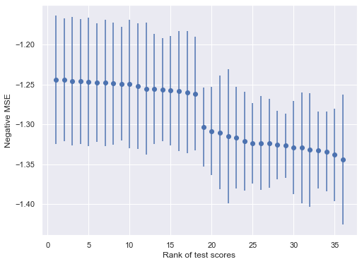

```python
results=pd.DataFrame(clf.cv_results_)[['param_activation','param_alpha','param_solver','param_learning_rate',\
                                       'mean_test_score','std_test_score','rank_test_score']].sort_values(by='rank_test_score')
display(results)

plt.figure(figsize=(8,6))
plt.errorbar(x=results.rank_test_score, y=results.mean_test_score, yerr=results.std_test_score, fmt='o')
plt.xlabel('Rank of test scores')
plt.ylabel('Negative MSE')
# plt.xticks(results.rank_test_score)
```